# Machine Learning Course : Exercise Prediction

Ryan Seal

November 22, 2015

# Introduction

- Class A : correctly performed curl according to specification,
- Class B : incorrectly performed curl throwing elbows out to the front
- Class C : incorrectly lifting the dumbbell half-way up.
- Class D : incorrectly lowering the dumbbell half-way down.
- Class E : incorrectly throwing the hips into the curl.

These movements were monitored using a set of accelerometers mounted in the following locations:

- glove,
- armband,
- lumbar belt, and
- dumbbell.

Features were selected by iterating through subsets of data visualized via the command. After a cursory examination, non-sparse variables were chosen and they were transformed by computing magnitudes of multi-axis data. The following snippet provides a summary of steps taken.

```r
train_features <- NULL
train_features$gbm <- sqrt(training$gyros_belt_x**2.0 + training$gyros_belt_y**2.0 + training$gyros_belt_z**2.0)
train_features$abm <- sqrt(training$accel_belt_x**2.0 + training$accel_belt_y**2.0 + training$accel_belt_z**2.0)
train_features$mbm <- sqrt(training$magnet_belt_x**2.0 + training$magnet_belt_y**2.0 + training$magnet_belt_z**2.0)
train_features$gdm <- sqrt(training$gyros_dumbbell_x**2.0 + training$gyros_dumbbell_y**2.0 + training$gyros_dumbbell_z**2.0)
train_features$adm <- sqrt(training$accel_dumbbell_x**2.0 + training$accel_dumbbell_y**2.0 + training$accel_dumbbell_z**2.0)
train_features$mdm <- sqrt(training$magnet_dumbbell_x**2.0 + training$magnet_dumbbell_y**2.0 + training$magnet_dumbbell_z**2.0)
train_features$roll_belt <- training$roll_belt
train_features$roll_dumbbell <- training$roll_dumbbell
train_features$classe <- training$classe
train_features$pitch_belt <- training$pitch_belt
```

Based on course experience (and lecture notes), a random forest algorithm is considered one of the best-performing algorithms and was used to build the prediction model. Variable importance was examined using to ensure that the chosen variables provided some level of importance. The number of trees in the fit was limited to 500. Cross validation is estimated internally with this algorithm and the Out-Of-Bag (OOB) error is provided when the model is fit (see output below).

```r
library(randomForest)
```

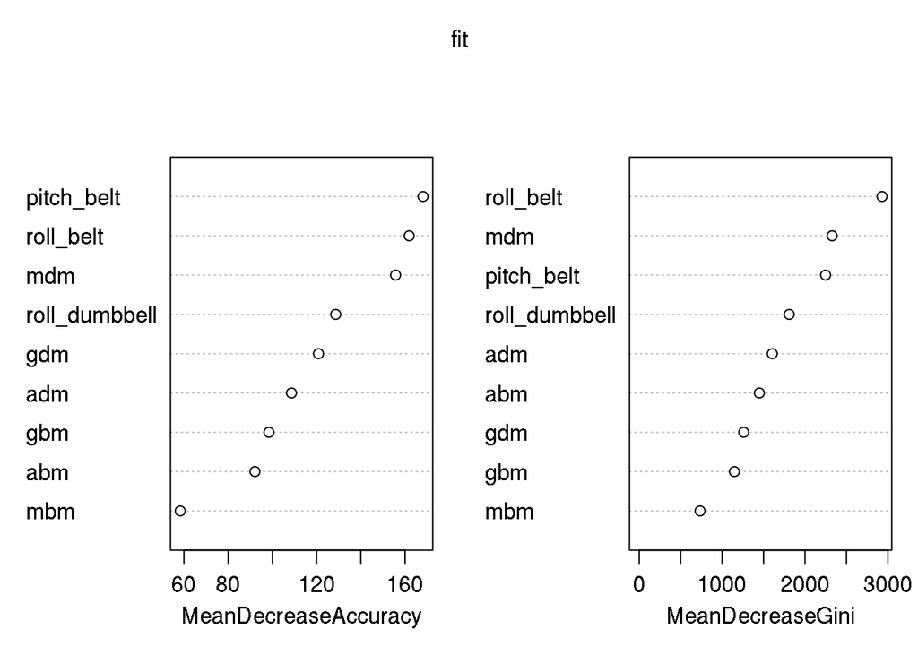

```r
fit <- randomForest(classe~.,data=train_features, importance=TRUE)
varImpPlot(fit)
```

```r
print(fit)
```

```
##
## Call:
##  randomForest(formula = classe ~ ., data = train_features, importance = TRUE)
##                Type of random forest: classification
##                      Number of trees: 500
## No. of variables tried at each split: 3
##
##         OOB estimate of  error rate: 6.54%
## Confusion matrix:
##      A    B    C    D    E class.error
## A 5352   73   50   90   15  0.04086022
## B  192 3465  109   30    1  0.08743745
## C   84   79 3092  159    8  0.09643483
## D  115   18  148 2929    6  0.08924129
## E   32   13   38   23 3501  0.02938730
```

Testing data was transformed and the model was applied.

```r
test_features <- NULL
test_features$gbm <- sqrt(testing$gyros_belt_x**2.0 + testing$gyros_belt_y**2.0 + testing$gyros_belt_z**2.0)
test_features$abm <- sqrt(testing$accel_belt_x**2.0 + testing$accel_belt_y**2.0 + testing$accel_belt_z**2.0)
test_features$mbm <- sqrt(testing$magnet_belt_x**2.0 + testing$magnet_belt_y**2.0 + testing$magnet_belt_z**2.0)
test_features$gdm <- sqrt(testing$gyros_dumbbell_x**2.0 + testing$gyros_dumbbell_y**2.0 + testing$gyros_dumbbell_z**2.0)
test_features$adm <- sqrt(testing$accel_dumbbell_x**2.0 + testing$accel_dumbbell_y**2.0 + testing$accel_dumbbell_z**2.0)
test_features$mdm <- sqrt(testing$magnet_dumbbell_x**2.0 + testing$magnet_dumbbell_y**2.0 + testing$magnet_dumbbell_z**2.0)
test_features$roll_belt <- testing$roll_belt
test_features$roll_dumbbell <- testing$roll_dumbbell
test_features$pitch_belt <- testing$pitch_belt
test_features$classe <- testing$classe
```

Testing values were written out for evaluation using the suggested snippet:

```r
results <- predict(fit, test_features)

for(i in 1:length(results)){
    filename = paste0("results/problem_id_",i,".txt")
    write.table(results[i],file=filename,quote=FALSE,row.names=FALSE,col.names=FALSE)
  }
```